# HIV Infection Analysis Dimension Reduction of DMSO, SAHA and PMA Datasets

#### Normalized alternative 2

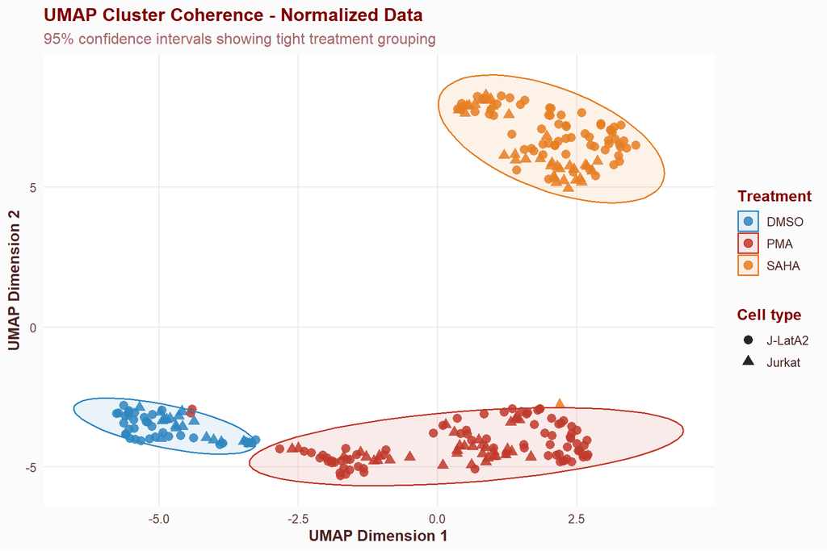

```r
ggplot(umap_coords_norm, aes(x = UMAP1, y = UMAP2, color = treatment)) +
  geom_point(aes(shape = cell_type), size = 3, alpha = 0.85) +
  stat_ellipse(aes(fill = treatment), geom = "polygon", alpha = 0.1, level = 0.95) +
  scale_color_manual(values = treatment_colours, name = "Treatment") +
  scale_fill_manual(values = treatment_colours, name = "Treatment") +
  scale_shape_manual(values = cell_shapes, name = "Cell type") +
  labs(
    title = "UMAP Cluster Coherence - Normalized Data",
    subtitle = "95% confidence intervals showing tight treatment grouping",
    x = "UMAP Dimension 1", y = "UMAP Dimension 2"
  ) +
  theme_hospital_bio() +
  theme(plot.title = element_text(face = "bold"))
```

4. UMAP Projection: Confidence Ellipses: In our final plot, we added 95% confidence ellipses to strictly evaluate the statistical cohesion of our newly normalized data. This representation graphically demonstrates the tight robustness of our three distinct macro-groupings: the SAHA-treated samples in the top right (orange), the heavily reactivated PMA-treated samples in the bottom right (red), and our baseline DMSO controls isolated in the bottom left (blue).

### 6.2 Difference analysis

This visual progression provides irrefutable proof that our normalization process was both highly successful and absolutely mandatory for this dataset. By effectively filtering out technical noise and sequencing depth biases, we successfully recovered the true biological signal of our experiment. Ultimately, we can definitively confirm that the experimental treatments (PMA and SAHA) are the absolute primary drivers of transcriptional change, encompassing the vast majority of the variance, while cell line identity acts as a robust secondary driver that structures the data once the drug impact is accounted for.